# Movement_Assignment4_Komatsu_Cooper

Cooper Komatsu

2023-10-24

# Introduction

## Research Question

How does time of year affect the distance of Divvy trips taken by riders? Which community areas are most affected by seasonal differences, and in what ways?

## Hypothesis

Divvy riders will take longer rides in the warmer months as temperatures rise, ice clears from the streets, and people either see Divvy as a more viable option or decide to take more pleasure rides.

# Setup

## Library Packages

```r
library(tidyverse)
library(dplyr)
library(sf)
library(tmap)
library(stplanr)
library(geosphere)
library(ggplot2)
library(ggpubr)
```

## Get Data

For the monthly data, I chose the most recently January (representing winter), April (representing spring), July (representing summer), and October (representing fall) in the Divvy dataset. These months were chosen in accordance to temperature variations in Chicago. July is the hottest month, while January is the coldest, and April and October fall in between. The data is from the Divvy Trip History Dataset (https://divvy-tripdata.s3.amazonaws.com/index.html), as Divvy is one of Chicago’s Transit Network Partners that it collects data from.

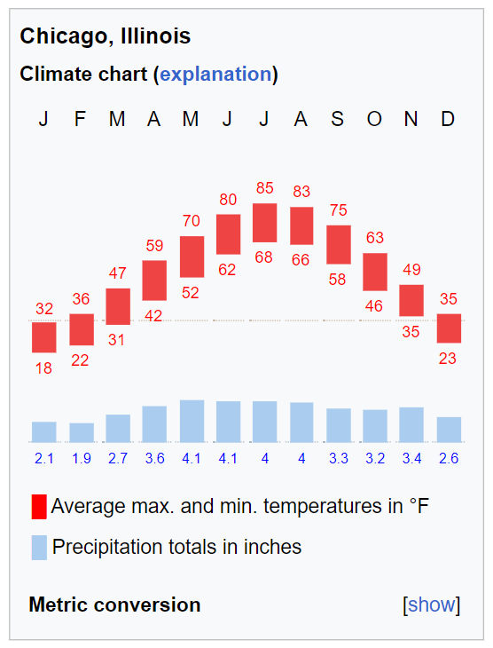

Chicago Climate Diagram

```r
# Divvy Data
jan <- read.csv("~/GISC 37104/Thurs_TransportDivvy/data/202301-divvy-tripdata.csv")
apr <- read.csv("~/GISC 37104/Thurs_TransportDivvy/data/202304-divvy-tripdata.csv")
jul <- read.csv("~/GISC 37104/Thurs_TransportDivvy/data/202207-divvy-tripdata.csv")
oct <- read.csv("~/GISC 37104/Thurs_TransportDivvy/data/202210-divvy-tripdata.csv")

#Community Areas
cas <- st_read("~/GISC 37104/Thurs_TransportDivvy/data/CommAreas.shp")
```

# Work with Data

## Refactor Data

This involved removing all rides with missing data for start or end station. These rides would not be helpful in conducting the analysis.

```r
# methods taken from "transportation_divvy_viz"

# replace blanks with NA values, rename shorter
jan <- jan %>% mutate_if(is.character, ~na_if(., ''))
apr <- apr %>% mutate_if(is.character, ~na_if(., ''))
jul <- jul %>% mutate_if(is.character, ~na_if(., ''))
oct <- oct %>% mutate_if(is.character, ~na_if(., ''))

# specify non-NA origins and destinations - dataset shrinks from 190301 to 148284 observations for january
jan_def <- jan %>%
  drop_na(start_station_id) %>%
  drop_na(end_station_id)
apr_def <- apr %>%
  drop_na(start_station_id) %>%
  drop_na(end_station_id)
jul_def <- jul %>%
  drop_na(start_station_id) %>%
  drop_na(end_station_id)
oct_def <- oct %>%
  drop_na(start_station_id) %>%
  drop_na(end_station_id)
```

## Calculate Distances

This step took quite a bit of searching and reading through documentation. I eventually settled on the distVincentySphere function in the geosphere package, which uses a datum to calculate the distance between two coordinates along the earth’s surface. I struggled with getting them in the right df format, but eventually it worked out.

```r
# Calculate distance with geosphere package and add it to the data

# January
o_coords_jan <- data.frame(lon = jan_def$start_lng, lat = jan_def$start_lat)
d_coords_jan <- data.frame(lon = jan_def$end_lng, lat = jan_def$end_lat)
jan_def$dists <- distVincentySphere(o_coords_jan, d_coords_jan)

# April
o_coords_apr <- data.frame(lon = apr_def$start_lng, lat = apr_def$start_lat)
d_coords_apr <- data.frame(lon = apr_def$end_lng, lat = apr_def$end_lat)
apr_def$dists <- distVincentySphere(o_coords_apr, d_coords_apr)

# July
o_coords_jul <- data.frame(lon = jul_def$start_lng, lat = jul_def$start_lat)
d_coords_jul <- data.frame(lon = jul_def$end_lng, lat = jul_def$end_lat)
jul_def$dists <- distVincentySphere(o_coords_jul, d_coords_jul)

# October
o_coords_oct <- data.frame(lon = oct_def$start_lng, lat = oct_def$start_lat)
d_coords_oct <- data.frame(lon = oct_def$end_lng, lat = oct_def$end_lat)
oct_def$dists <- distVincentySphere(o_coords_oct, d_coords_oct)
```

## Plot Histogram of Distance Distribution

```r
# Include a red mean line to better show how mean distance traveled changes across months
# Include appropriate breaks, labels, and title

jan_dists <- ggplot(jan_def, aes(x = dists, y = after_stat(density))) +
  geom_histogram(breaks = c(0,500,1000,1500,2000,2500,3000,3500,4000,4500,5000)) +
  geom_vline(xintercept = mean(jan_def$dists), color = "red", linetype = "dashed", size = 1) +
  labs(x = "Distance Traveled (m)", y = "Frequency") +
  ggtitle("Divvy Distance Distribution by Month") +
  theme(plot.title = element_text(hjust = 0.5, vjust = 1))
apr_dists <- ggplot(apr_def, aes(x = dists, y = after_stat(density))) +
  geom_histogram(breaks = c(0,500,1000,1500,2000,2500,3000,3500,4000,4500,5000)) +
  geom_vline(xintercept = mean(apr_def$dists), color = "red", linetype = "dashed", size = 1) +
  labs(x = "Distance Traveled (m)", y = "Frequency")
jul_dists <- ggplot(jul_def, aes(x = dists, y = after_stat(density))) +
  geom_histogram(breaks = c(0,500,1000,1500,2000,2500,3000,3500,4000,4500,5000)) +
  geom_vline(xintercept = mean(jul_def$dists), color = "red", linetype = "dashed", size = 1) +
  labs(x = "Distance Traveled (m)", y = "Frequency")
oct_dists <- ggplot(oct_def, aes(x = dists, y = after_stat(density))) +
  geom_histogram(breaks = c(0,500,1000,1500,2000,2500,3000,3500,4000,4500,5000)) +
  geom_vline(xintercept = mean(oct_def$dists), color = "red", linetype = "dashed", size = 1) +
  labs(x = "Distance Traveled (m)", y = "Frequency")
```

```r
ggarrange(jan_dists, apr_dists, jul_dists, oct_dists + rremove("x.text"),
          labels = c("January", "April", "July", "October"),
          ncol = 1, nrow = 4)
```

[figure not shown]

## Spatialize and Plot Data

For this product, I wanted a choropleth map of Chicago community areas, according to the mean distance traveled from Divvy stations in that community area. To do that, I had to aggregate the monthly Divvy data within community areas by their origin points.

```r
# Methods influenced by "transportation-divvy-viz".

# January
jan_o_spatial <- jan_def %>%
  select("ride_id", "start_station_id", "end_station_id","start_lat","start_lng","end_lat","end_lng","dists") %>%
  st_as_sf(coords=c("start_lng", "start_lat"), crs = 4326) # Select useful columns, spatialize origin lat/long as points
jan_o_spatial <- st_transform(jan_o_spatial,3435) # Directly spatializing into the CRS EPSG:3435 put the points in Southern Missouri, so I had to load them in 4326 first, then transform to 3435

jan_agg <- aggregate(x=jan_o_spatial, by=cas, FUN=mean) # Aggregate data to community area
jan_agg$dists <- jan_agg$dists/1000 # Convert from m to km

# April
apr_o_spatial <- apr_def %>%
  select("ride_id", "start_station_id", "end_station_id","start_lat","start_lng","end_lat","end_lng","dists") %>%
  st_as_sf(coords=c("start_lng", "start_lat"), crs = 4326) # x = longitude, y = latitude
apr_o_spatial <- st_transform(apr_o_spatial,3435)

apr_agg <- aggregate(x=apr_o_spatial, by=cas, FUN=mean)
apr_agg$dists <- apr_agg$dists/1000

# July
jul_o_spatial <- jul_def %>%
  select("ride_id", "start_station_id", "end_station_id","start_lat","start_lng","end_lat","end_lng","dists") %>%
  st_as_sf(coords=c("start_lng", "start_lat"), crs = 4326) # x = longitude, y = latitude
jul_o_spatial <- st_transform(jul_o_spatial,3435)

jul_agg <- aggregate(x=jul_o_spatial, by=cas, FUN=mean)
jul_agg$dists <- jul_agg$dists/1000

# October
oct_o_spatial <- oct_def %>%
  select("ride_id", "start_station_id", "end_station_id","start_lat","start_lng","end_lat","end_lng","dists") %>%
  st_as_sf(coords=c("start_lng", "start_lat"), crs = 4326) # x = longitude, y = latitude
oct_o_spatial <- st_transform(oct_o_spatial,3435)

oct_agg <- aggregate(x=oct_o_spatial, by=cas, FUN=mean)
oct_agg$dists <- oct_agg$dists/1000
```

## Make Maps

```r
# Create tmaps with appropriate breaks, titles, and labels

jan_dists_ca <- tm_shape(jan_agg) +
  tm_fill("dists", breaks = c(0,1,1.5,2,2.5,3,3.5,4,5),title="Distance (km)", title.position = "top") +
  tm_layout(title = "Mean Divvy Ride Distances: 01/2023")
apr_dists_ca <- tm_shape(apr_agg) +
  tm_fill("dists", breaks = c(0,1,1.5,2,2.5,3,3.5,4,5),title="Distance (km)", title.position = "top") +
  tm_layout(title = "Mean Divvy Ride Distances: 04/2023")
jul_dists_ca <- tm_shape(jul_agg) +
  tm_fill("dists", breaks = c(0,1,1.5,2,2.5,3,3.5,4,5),title="Distance (km)", title.position = "top") +
  tm_layout(title = "Mean Divvy Ride Distances: 07/2022")
oct_dists_ca <- tm_shape(oct_agg) +
  tm_fill("dists", breaks = c(0,1,1.5,2,2.5,3,3.5,4,5),title="Distance (km)", title.position = "top") +
  tm_layout(title = "Mean Divvy Ride Distances: 10/2022")
```

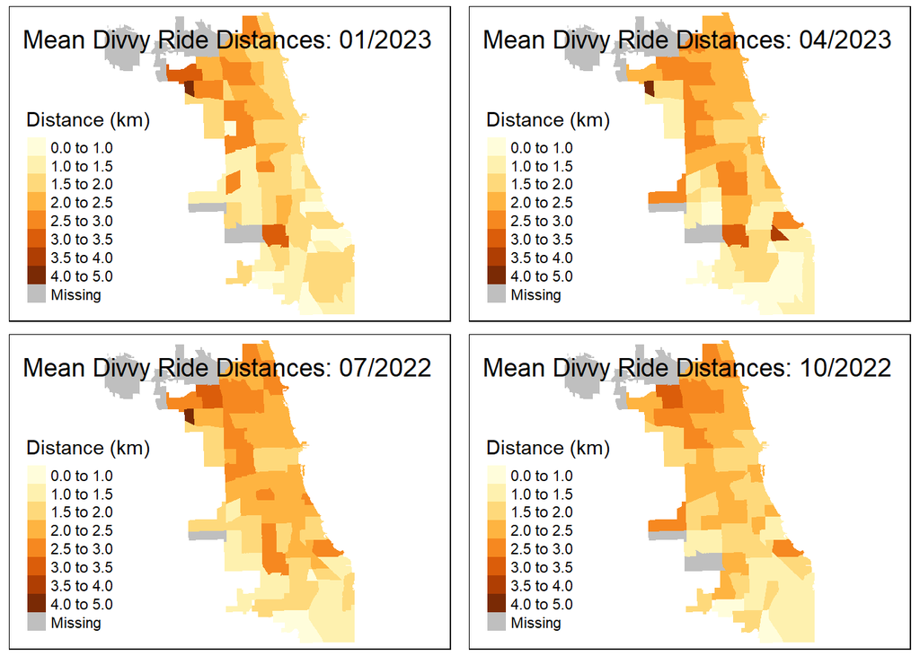

```r
# Arrange maps

tmap_arrange(jan_dists_ca, apr_dists_ca, jul_dists_ca, oct_dists_ca, nrow = 2, ncol = 2)
```